# Datos univariados y su distribución

Felipe González

### Homogeneidad y pooling

En la descripción de los cantantes que produjimos arriba hicimos una comparación de la distribución de los residuales en cada grupo y concluimos que todos tenían, aproximadamente, distribución normal con la misma dispersión.

Lo que descubrimos es que los residuales son **homogéneos**. Un aspecto importante de este descubrimiento es que cuando observamos homogeneidad podemos hacer **pooling**, y cuando hacemos *pooling* podemos describir de manera más precisa la estructura comñun que encontramos.

En el ejemplo de propinas, podríamos describir parte de la dispersión agrupando hombres y mujeres, y dar los cuartiles a total:

```r
round(quantile(tips$prop), 2)
```

```
  0%  25%  50%  75% 100%
0.04 0.13 0.15 0.19 0.71
```

Esta descripción es más robusta pues utiliamos *todos* los datos para construirla, y además es más simple que dar resúmenes por grupo.

En nuestro ejemplo de los cantantes, *pooling* quiere decir que una vez que eliminamos el desplazamiento de las medias entre los grupos, es posible usar el total de los datos para describir variación que encontramos en los residuales. Esto hace que nuestra descripción de los residuales sea más precisa o informativa, pues usamos la variación de *todos* los residuales para describir su variación.

¿Cómo decidir si podemos hacer *pooling*?

### Gráficas qq y pooling

Una manera eficiente de investigar si es posible agrupar conjuntos de datos para describir su distribución común es haciendo gráficas qq de los cuantiles de cada grupo contra los cuantiles agrupados:

```r
library(ggplot2)
library(lattice)
library(dplyr)
# calculamos la estatura en centímetros
singer$estatura.m <- singer$height * 2.54

# calculamos el valor f dentro de cada grupo
singer_ord <- arrange(group_by(singer, voice.part), estatura.m)
singer_ajuste <- mutate(singer_ord,
  media = mean(estatura.m),
  residual = estatura.m - media,
  mediana = median(estatura.m),
  mediana_residual = median(residual))
```

```r
todos_residual <- sort(singer_ajuste$residual)
singer_ajuste
```

```
Source: local data frame [235 x 7]
Groups: voice.part

   height voice.part estatura.m media residual mediana mediana_residual
1      66     Bass 2      167.6 181.3  -13.677   182.9            1.563
2      67     Bass 2      170.2 181.3  -11.137   182.9            1.563
3      67     Bass 2      170.2 181.3  -11.137   182.9            1.563
4      68     Bass 2      172.7 181.3   -8.597   182.9            1.563
5      68     Bass 2      172.7 181.3   -8.597   182.9            1.563
6      69     Bass 2      175.3 181.3   -6.057   182.9            1.563
7      70     Bass 2      177.8 181.3   -3.517   182.9            1.563
8      70     Bass 2      177.8 181.3   -3.517   182.9            1.563
9      70     Bass 2      177.8 181.3   -3.517   182.9            1.563
10     70     Bass 2      177.8 181.3   -3.517   182.9            1.563
..    ...        ...        ...   ...      ...     ...              ...
```

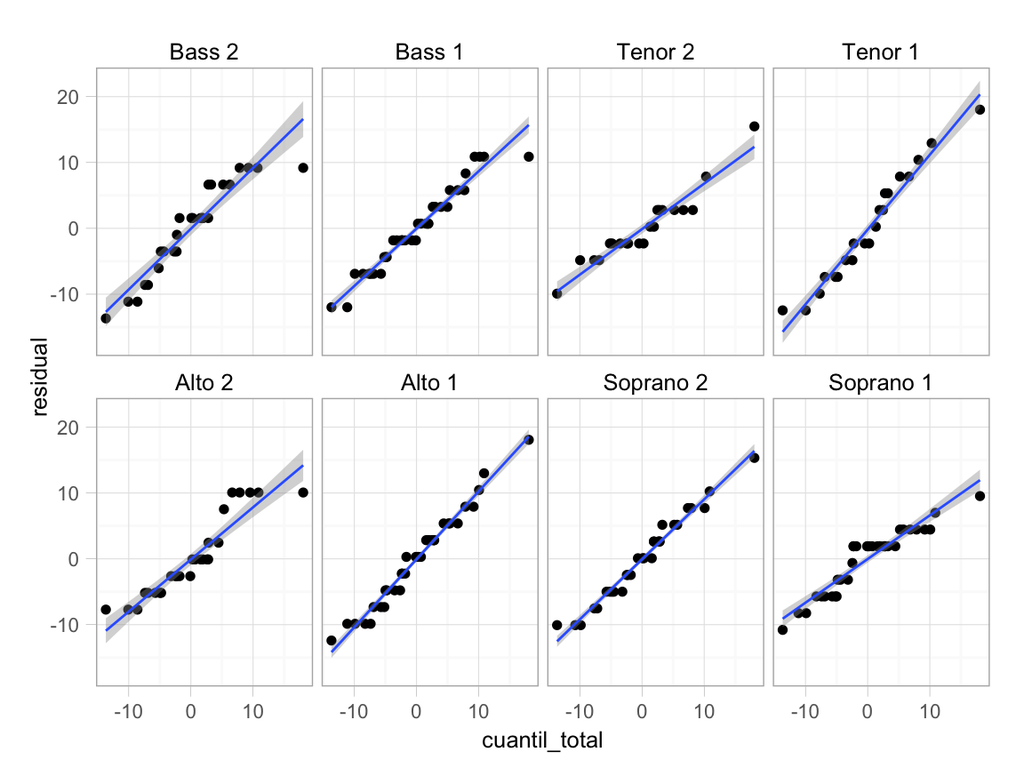

```r
singer_total <- singer_ajuste %>%
  arrange(residual) %>%
  mutate(
    n_obs = n(),
    cuantil_total = approx(x = 1:length(todos_residual), y = todos_residual,
      n = n_obs[1])$y
  )

ggplot(singer_total, aes(x = cuantil_total, y = residual)) +
  geom_point() +
  facet_wrap(~ voice.part, nrow = 2) +
  stat_smooth(method = "lm")
```

Esta gráfica confirma que a distribución de los residuales agrupados describe apropiadamente los residuales dentro de cada grupo.

### Ajuste de la distribución normal

Gracias al paso anterior, hacer *pooling* de los residuales está justificado, así que para entender la variación de los residuales podemos usar el total de los residuales.

Ahora podemos hacer una gráfica qq normal para ver si el modelo normal es adecuado para describir la distribución de los residuales:

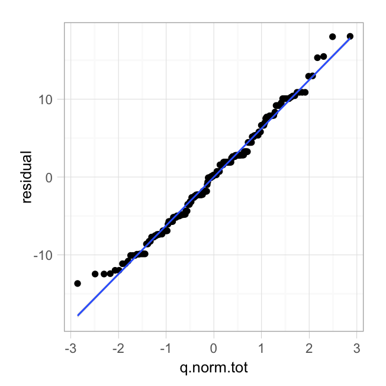

```r
n <- nrow(singer_total)
singer_normal <- singer_total %>%
  ungroup() %>%
  arrange(residual) %>%
  mutate(
    valor.f.tot = (seq(1, n) - 0.5) / n,
    q.norm.tot = qnorm(valor.f.tot)
  )
ggplot(singer_normal, aes(x = q.norm.tot, y = residual)) +
  geom_point() +
  stat_smooth(method = "lm")
```

Donde vemos que la distribución normal es adecuada para describir la distribución de los residuales agrupados.

Para estimar la desviación estándar de los residuales usamos la cantidad:

$\sqrt{\frac{1}{n-8}\sum_{p=1}^8\sum_{i}\hat{\epsilon}_{pi}^2}$

que es igual a:

```r
s <- round(sqrt(sum(singer_normal$residual ^ 2)/(nrow(singer_normal) - 8)), 1)
s
```

```
[1] 6.4
```

Notemos que dividimos entre $n-8$ (8 es el número de grupos), de forma que el estimador $s^2$ sea un estimador insesgado de la varianza de los residuales agrupados (esto es consecuencia de que los residuales se calculan con medias *estimadas*, pues no conocemos las reales).

### Gráfica de dispersión de ajuste y residuales

Ahora podemos comparar cuánta variación de los datos está explicada por la tesitura y cuanta se absorbe en los residuales. Dos escenarios extremos son: 1) los individuos dentro de cada grupo no varían, pero las medias de los grupos son diferentes, y 2) las medias de los grupos no cambian y todos los individuos varían alrededor de esa misma media común.

Una forma eficiente de hacer esta comparación es graficando, lado a lado, los cuantiles de los valores ajustados y de los residuales. Centramos los valores ajustados por la media general para poder comparar mejor:

```r
library(tidyr)

# primero agrupamos por tesitura para calcular el valor ajustado (meida de
# grupo) y el residual (media - estatura)
singer_ajuste <- singer %>%
  group_by(voice.part) %>%
  mutate(
    ajustado = mean(estatura.m),
    residual = estatura.m - ajustado
  ) %>%
  ungroup() %>% # desagrupamos para centrar por media general
  mutate(
    id = 1:nrow(singer),
    ajustado.c = ajustado - mean(ajustado)
  )

singer_ajuste
```

```
Source: local data frame [235 x 7]

   height voice.part estatura.m ajustado residual id ajustado.c
1      64  Soprano 1      162.6    163.2   -0.635  1     -7.742
2      62  Soprano 1      157.5    163.2   -5.715  2     -7.742
3      66  Soprano 1      167.6    163.2    4.445  3     -7.742
4      65  Soprano 1      165.1    163.2    1.905  4     -7.742
5      60  Soprano 1      152.4    163.2  -10.795  5     -7.742
6      61  Soprano 1      154.9    163.2   -8.255  6     -7.742
7      65  Soprano 1      165.1    163.2    1.905  7     -7.742
8      66  Soprano 1      167.6    163.2    4.445  8     -7.742
9      65  Soprano 1      165.1    163.2    1.905  9     -7.742
10     63  Soprano 1      160.0    163.2   -3.175 10     -7.742
..    ...        ...        ...      ...      ... ..        ...
```

```r
# creamos un data.frame alargado con las variables que queremos graficar
singer_ajuste_long <- singer_ajuste %>%
  select(id, ajustado.c, residual) %>%
  gather(variable, valor, ajustado.c, residual)

singer_ajuste_long
```

```
Source: local data frame [470 x 3]

   id   variable  valor
1   1 ajustado.c -7.742
2   2 ajustado.c -7.742
3   3 ajustado.c -7.742
4   4 ajustado.c -7.742
5   5 ajustado.c -7.742
6   6 ajustado.c -7.742
7   7 ajustado.c -7.742
8   8 ajustado.c -7.742
9   9 ajustado.c -7.742
10 10 ajustado.c -7.742
.. ..        ...    ...
```

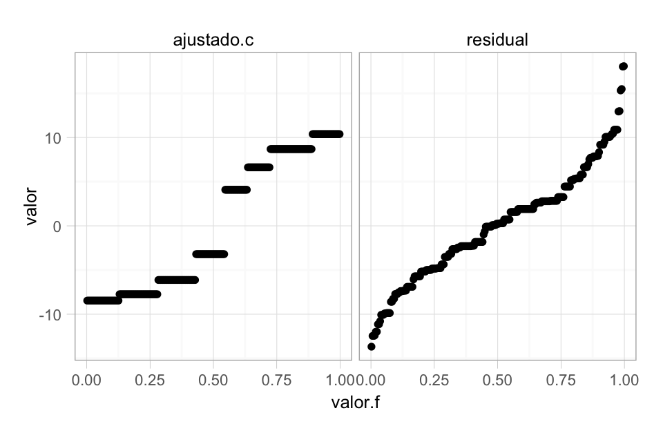

```r
# y calculamos los cuantiles
singer_ajuste_cuant <- singer_ajuste_long %>%
  group_by(variable) %>%
  arrange(valor) %>%
  mutate(
    n = n(),
    valor.f = (1:n[1] -0.5)/n[1]
  )

ggplot(singer_ajuste_cuant, aes(x = valor.f, y = valor)) +
  geom_point() +
  facet_wrap(~ variable)
```

Es así que una gráfica de dispersión de residuales y ajustados consiste en dos gráficas de cuantiles, construidas con la misma escala. En una de ellas se grafican los valores ajustados centrados por la media general, y en el otro los residuales.

Comparamos estas dos gráficas para ver cuánta de la variación en los datos se explica mediante el modelo que ajustamos, y cuánta se queda en los residuales. También es útil leer los cuantiles de los residuales en esta gráfica.

### Las 4 R’s del análisis exploratorio

Tukey creó una lista de cuatro R’s para sus métodos del análisis exploratorio donde describe cuatro aspectos fundamentales:

- **Resistencia**: deben estar basados en técnicas resistentes a datos atípicos y comportarse bien cuando ocurren otros tipos de no-normalidad.
- **Revelar**: deben mostrar unequívocamente lo esperado o usual, y ser capaces de mostrar claramente patrones novedosos o inesperados en los datos.
- **Residuales**: deben proceder eliminando variación identificada y examinando los residuales que resultan. Si podemos identificar variación en los residuales, la eliminamos e iteramos nuevamente.
- **Reexpresión**: los datos no siempre esrán dados en las unidades más convenientes para su análisis o visualización, y muchas veces es necesario reexpresarlos de alguna forma.

Ya hemos discutido que los conjuntos de datos reales requieren métodos resistentes para su exploración (más adelante discutiremos métodos de suavizamiento resistentes), y también hemos visto que gráficas y resúmenes simples pueden revelar con claridad hasta los aspectos más sutiles de varios conjutos de datos.

El ejemplo de los cantantes es la sección anterior fue el primer encuentro con residuales. La idea de los residuales, resumiendomm es identificar fuentes de variación, eliminarlas, y analizar los residuales resultantes buscando otras fuentes de variación adicionales: en cada paso simplificamos el problema al eliminar fuentes de variación conocida. Como vimos, la idea general es escribir

Valor observado = Valor ajustado + Residual

y analizar los residuales resultantes. Todo esto lo hacemos en un proceso iterativo de ajuste-exploración-resumen.

### Transformaciones

Como hemos visto, hay una gran variedad de formas que se pueden observar en conjuntos de datos reales (multimodales, colas largas, etc.). Muchas veces es posible simplificar la estructura de variación en los datos transformados con una función simple, lo que hace mucho más fácil el análisis y la descripción.

Una familia útil de transformaciones es la siguiente:

La **familia de transformaciones de Box Cox** con parámetro $p$ se define como:

$\begin{equation} T_p(x)=\begin{cases} \frac{x^p-1}{p}, & \text{si $p \ne 0$}.\\ log(x), & \text{si $p = 0$}. \end{cases} \end{equation}$

En la práctica podemos usar simplemente $x \to x^p$, pues el reescalamiento y desplazamiento adicional no cambian la forma de la distribución de los datos, sólo su dispersión y tendencia central. Generalmente no es necesario usar transformaciones más complejas que las de Cox-Box, al menos en la parte exploratoria.

### El logaritmo

Consideremos los datos de cuentas de un restaurante, clasificadas según sea una pareja o un grupo de 3 o más personas. Intentamos primero hacer algo similar a lo que hicimos con los cantantes:

```r
tips_grupo <- tips %>%
  filter(size > 1) %>%
  mutate(tipo_grupo = ifelse(size == 2, "Pareja", "Grupo"))

# vemos el tamaño de cada grupo
table(tips_grupo$tipo_grupo)
```

```
 Grupo Pareja
    84    156
```

Comenzamos considerando la distribución de los valores dentro de cada grupo:

```r
tips_cuantiles <- tips_grupo %>%
  group_by(tipo_grupo) %>%
  arrange(total_bill) %>%
  mutate(
    n = n(),
    valor_f = (1:n[1] - 0.5) / n[1],
    qnorm_gpo = qnorm(valor_f)
  )
tips_cuantiles
```

```
Source: local data frame [240 x 12]
Groups: tipo_grupo

   total_bill  tip    sex smoker  day   time size   prop tipo_grupo  n
1       10.33 1.67 Female     No  Sun Dinner    3 0.1617      Grupo 84
2       10.34 1.66   Male     No  Sun Dinner    3 0.1605      Grupo 84
3       15.69 3.00   Male    Yes  Sat Dinner    3 0.1912      Grupo 84
4       15.98 3.00 Female     No  Fri  Lunch    3 0.1877      Grupo 84
5       16.04 2.24   Male     No  Sat Dinner    3 0.1397      Grupo 84
6       16.21 2.00 Female     No  Sun Dinner    3 0.1234      Grupo 84
7       16.29 3.71   Male     No  Sun Dinner    3 0.2277      Grupo 84
8       16.31 2.00   Male     No  Sat Dinner    3 0.1226      Grupo 84
9       16.47 3.23 Female    Yes Thur  Lunch    3 0.1961      Grupo 84
10      16.49 2.00   Male     No  Sun Dinner    4 0.1213      Grupo 84
..        ...  ...    ...    ...  ...    ...  ...    ...        ... ..
Variables not shown: valor_f (dbl), qnorm_gpo (dbl)
```

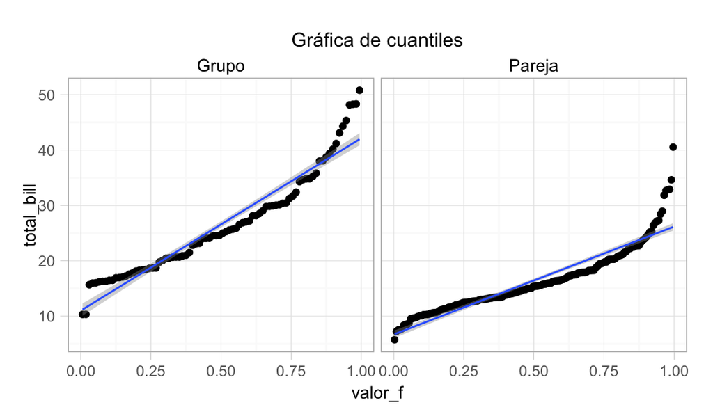

```r
ggplot(tips_cuantiles, aes(x = valor_f, y = total_bill)) +
  geom_point() +
  geom_smooth(method = "lm") +
  facet_wrap(~ tipo_grupo) +
  labs(title = "Gráfica de cuantiles")
```

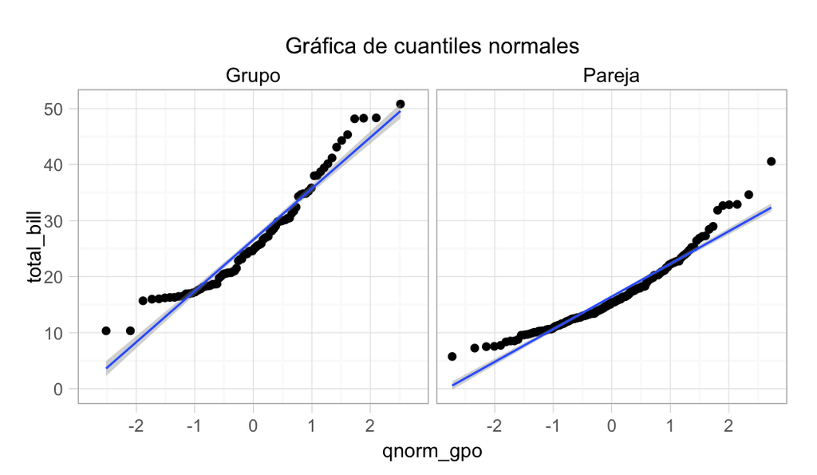

```r
ggplot(tips_cuantiles, aes(x = qnorm_gpo, y = total_bill)) +
  geom_point() +
  geom_smooth(method = "lm") +
  facet_wrap(~ tipo_grupo) +
  labs(title = "Gráfica de cuantiles normales")
```

1. ¿La aproximación normal es razonable?
1. Sí.
2. No.
2. La gráfica es:
1. Simétrica.
2. Sesgada a la derecha.
3. Sesgada a la izquierda.
3. Las medianas son:
1. Similares.
2. Mayor para parejas.
3. Mayor para grupos.
4. ¿Qué grupo presenta mayor variación?
1. Similar en ambos.
2. Mayor para parejas.
3. Mayor para grupos.

**Sesgo a la derecha.** En análisis es común encontrar conjuntos de datos sesgados, esto representa varios problemas:

- Problemas de visualización: cuando el sesgo es severo, la mayor parte de la gráfica se destina a la variación de unos pocos datos. El resto se aplasta en regiones chicas de la gráfica.
- Es más complicado describir datos sesgados: además de la tendencia central y la dispersión, hay que describir el sesgo.
- No es posible utilizar métodos usuales con base en la distribución normal.

Otro aspecto común es que los grupos con valores más grandes varían más, podemos observar esto en la siguiente gráfica:

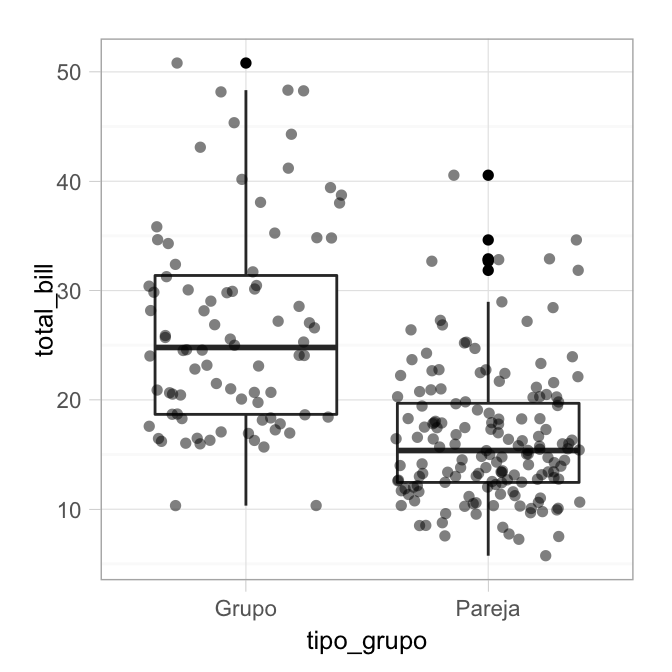

```r
ggplot(tips_grupo, aes(x = tipo_grupo, y = total_bill)) +
  geom_boxplot() +
  geom_jitter(alpha = 0.5)
```

En este caso, la variación que encontramos en el grupo *Grupo* parece ser del doble que en el grupo *Pareja*.

**Dispersión monótona.** Los conjuntos de datos sesgados muchas veces presentan dispersión monótona: grupos de datos con valores más grandes presentan más dispersión que grupos de datos con valores chicos. Esto acarrea problemas similares a los discutidos arriba:

- Problmeas de visualización: cuando el sesgo es severo, la mayor parte de la gráfica se destina a la variación de unos pocos datos. El resto se aplasta en regiones chicas de la gráfica.
- Es más complicado describir los datos con dispersión monótona: en este caso no es posible hacer *pooling** de la dispersión de los grupos.

Estos dos problemas (sesgo y dispersión monótona) generalmente vienen juntos, y usualmente pueden corregirse transformando los datos. Por ejemplo, si aplicamos el logaritmo a los datos, obtenemos:

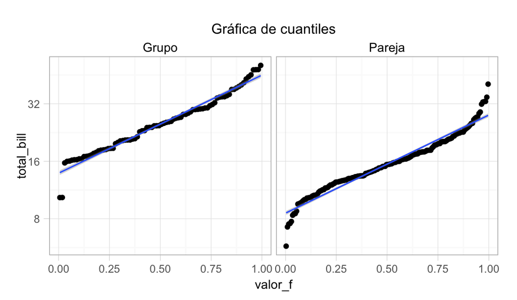

```r
ggplot(tips_cuantiles, aes(x = valor_f, y = total_bill)) +
  geom_point() +
  facet_wrap(~ tipo_grupo) +
  stat_smooth(method=lm) +
  labs(title='Gráfica de cuantiles') +
  scale_y_log10(breaks = c(4, 8, 16, 32, 64))
```

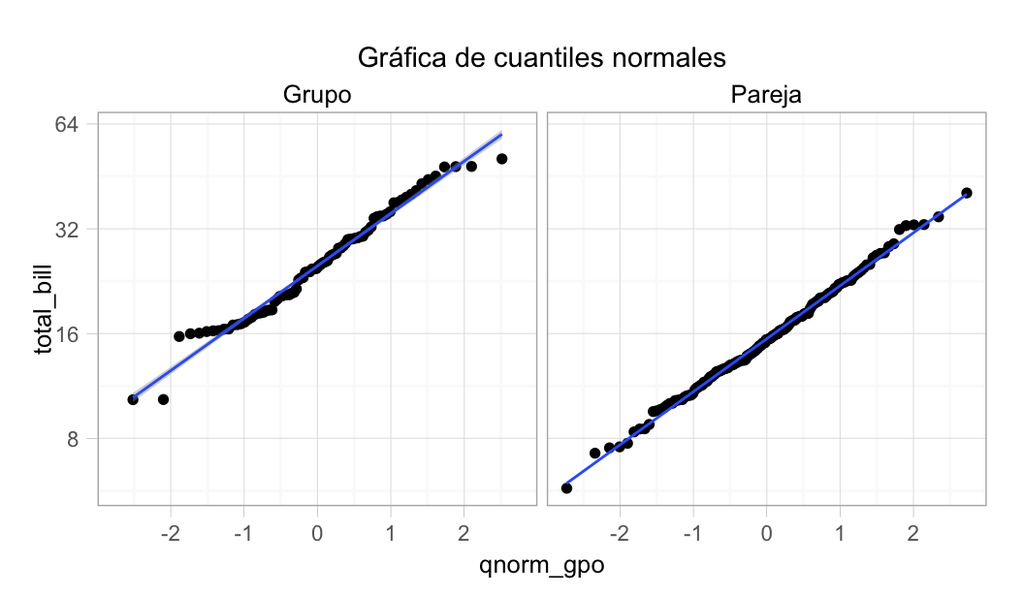

```r
ggplot(tips_cuantiles, aes(x = qnorm_gpo, y = total_bill)) +
  geom_point() +
  facet_wrap(~ tipo_grupo) +
  stat_smooth(method=lm) +
  labs(title='Gráfica de cuantiles normales') +
  scale_y_log10(breaks = c(4, 8, 16, 32, 64))
```

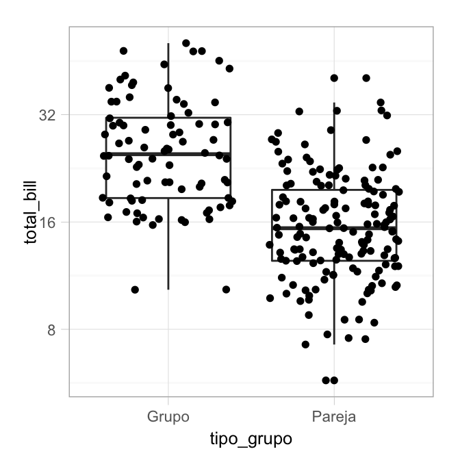

```r
ggplot(tips_grupo, aes(x = tipo_grupo, y = total_bill)) +
  geom_boxplot() +
  geom_jitter() +
  scale_y_log10(breaks = c(4, 8, 16, 32, 64))
```

Y observamos que tanto el sego como la dispersión monótona han desaparecido. Entonces, la ventaja de esta transformación es que podemos obtener una descripción eficiente y clara de estos datos. La desventaja potencial es que tenemos que trabajar con el logaritmo de los datos.

Ahora revisaremos que, en efecto, los residuales agrupados describen razonablemente bien a los residuales de cada grupo. Nótese que como antes, usamos el logaritmo para todo nuestro análisis.

```r
# agregamos columnas de valores ajustados y residuales
tips_ajuste <- tips_cuantiles %>%
  mutate(
    total_ajustado = mean(log10(total_bill)),
    total_residual = log10(total_bill) - total_ajustado
    )
tips_ajuste
```

```
Source: local data frame [240 x 14]
Groups: tipo_grupo

   total_bill  tip    sex smoker  day   time size   prop tipo_grupo  n
1       10.33 1.67 Female     No  Sun Dinner    3 0.1617      Grupo 84
2       10.34 1.66   Male     No  Sun Dinner    3 0.1605      Grupo 84
3       15.69 3.00   Male    Yes  Sat Dinner    3 0.1912      Grupo 84
4       15.98 3.00 Female     No  Fri  Lunch    3 0.1877      Grupo 84
5       16.04 2.24   Male     No  Sat Dinner    3 0.1397      Grupo 84
6       16.21 2.00 Female     No  Sun Dinner    3 0.1234      Grupo 84
7       16.29 3.71   Male     No  Sun Dinner    3 0.2277      Grupo 84
8       16.31 2.00   Male     No  Sat Dinner    3 0.1226      Grupo 84
9       16.47 3.23 Female    Yes Thur  Lunch    3 0.1961      Grupo 84
10      16.49 2.00   Male     No  Sun Dinner    4 0.1213      Grupo 84
..        ...  ...    ...    ...  ...    ...  ...    ...        ... ..
Variables not shown: valor_f (dbl), qnorm_gpo (dbl), total_ajustado (dbl),
  total_residual (dbl)
```

```r
# ordenamos los residuales a total (es decir ignorando los grupos)
todos_residual <- sort(tips_ajuste$total_residual)
# creamos los cuantiles a total (interpolando) que compararemos con cada grupo
tips_ajuste_cuantil <- tips_ajuste %>%
  arrange(total_residual) %>%
  mutate(
    n_obs = n(),
    cuantil_total = approx(x = 1:length(todos_residual), y = todos_residual,
      n = n_obs[1])$y
  )
tips_ajuste_cuantil
```

```
Source: local data frame [240 x 16]
Groups: tipo_grupo

   total_bill  tip    sex smoker  day   time size   prop tipo_grupo  n
1       10.33 1.67 Female     No  Sun Dinner    3 0.1617      Grupo 84
2       10.34 1.66   Male     No  Sun Dinner    3 0.1605      Grupo 84
3       15.69 3.00   Male    Yes  Sat Dinner    3 0.1912      Grupo 84
4       15.98 3.00 Female     No  Fri  Lunch    3 0.1877      Grupo 84
5       16.04 2.24   Male     No  Sat Dinner    3 0.1397      Grupo 84
6       16.21 2.00 Female     No  Sun Dinner    3 0.1234      Grupo 84
7       16.29 3.71   Male     No  Sun Dinner    3 0.2277      Grupo 84
8       16.31 2.00   Male     No  Sat Dinner    3 0.1226      Grupo 84
9       16.47 3.23 Female    Yes Thur  Lunch    3 0.1961      Grupo 84
10      16.49 2.00   Male     No  Sun Dinner    4 0.1213      Grupo 84
..        ...  ...    ...    ...  ...    ...  ...    ...        ... ..
Variables not shown: valor_f (dbl), qnorm_gpo (dbl), total_ajustado (dbl),
  total_residual (dbl), n_obs (int), cuantil_total (dbl)
```

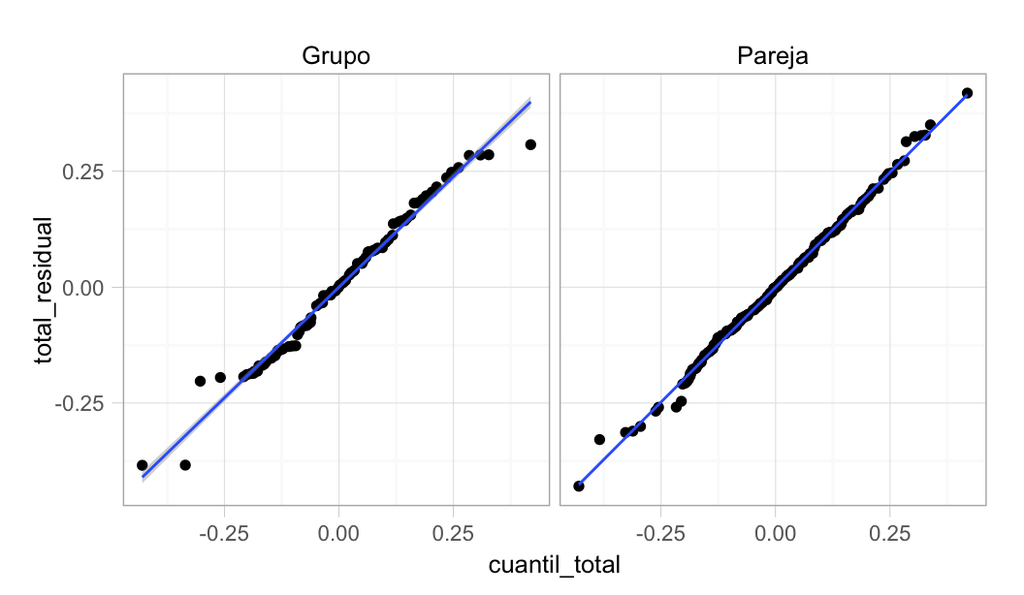

```r
ggplot(tips_ajuste_cuantil, aes(x = cuantil_total, y = total_residual)) +
  geom_point() +
  facet_wrap(~tipo_grupo, nrow=1) +
  geom_smooth(method = "lm")
```

Donde vemos que los residuales agrupados describen razonablemente bien los residuales de cada grupo. La distribución de residuales en el grupo *Grupo* tiene colas más cortas y dos posibles valores muy bajos que podríamos investigar (son dos cuentas de casi la misma cantidad 10.34 y 10.33).

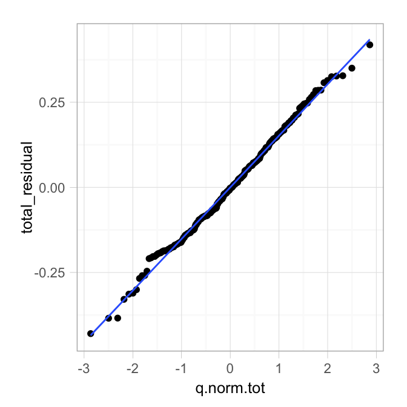

Ahora observamos la gráfica de dispersión de ajustados y residuales, donde observamos que aún cuando eliminamos el efecto de tipo de grupo, resta variación considerable en los residuales: es decir, tipo de grupo explica relativamente poco en la variación de las cantidades de las cuantes de este restaurante.

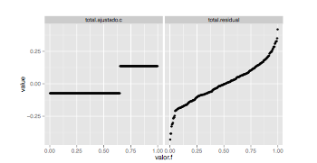

### Ejemplo: ventas

En este ejemplo consideramos las ventas en unidades realizadas en los viernes de tres años para cada estado (estos son datos reales). Comenzamos haciendo diagramas de caja y brazos (hay más de 1000 observaciones para cada estado):

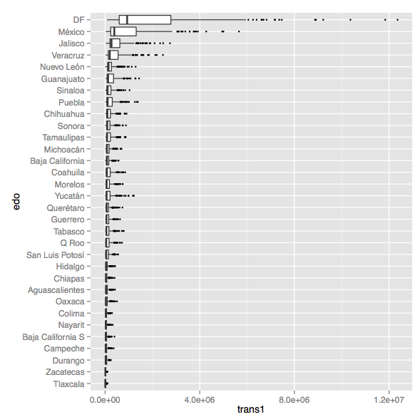

```r
load(file = './datos/ventas.Rdata')
ventas_viernes <- filter(ventas, diadesem = 'vie')

# ordenamos los estados de acuerdo a la mediana de ventas
ventas_viernes$edo <- reorder(as.character(ventas_viernes$edo),
  ventas_viernes$trans1, median, na.rm=TRUE)

ggplot(ventas_viernes, aes(x=edo, y = trans1)) +
  geom_boxplot(outlier.size = 1) +
  coord_flip()
```

Notamos que el sesgo es severo, y los distintos estados varían a lo largo de distintos órdenes de magnitud. Un efecto indeseable de este hecho es que el espacio en la gráfica es absorbido por unos cuantos puntos de datos, y la mayor parte de la variación de la mayoría de los estados se aplasta y no se puede apreciar.

Podemos ver que la solución no es quitar los estados grandes para poder ver los demás, pues sucede lo mismo a la siguiente escala de magnitud.

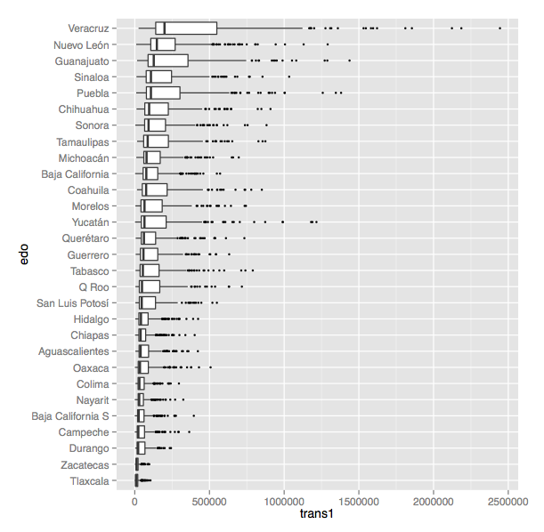

```r
ventas_sub <- filter(ventas_viernes, !(edo %in% c('DF', 'México', 'Jalisco'))) ventas_sub$edo <- reorder(as.character(ventas_sub$edo), ventas_sub$trans1,
  median, na.rm = TRUE)
ggplot(ventas.sub, aes(x = edo, y = trans1)) +
  geom_boxplot(outlier.size = 1) +
  coord_flip()
```

¿Qué pasa si transformamos a logaritmo? Esperamos que la varianza se estabilice a lo largo de los grupos, y que la asimetría se reduzca, y así es:

[figure not shown]

```r
ggplot(ventas_sub, aes(x = edo, y = log(trans1))) +
  geom_boxplot(outlier.size = 1) +
  coord_flip()
```

Cuando usamos logaritmo es posible seguir la siguiente interpretación:

La diferencia de dos cantidades $x$ y $x + \Delta$ en escala logarítmica es:

$log(x+ \Delta x) - log(x) = log\big(\frac{x + \Delta x}{x}\big) = log\big(1 + \frac{\Delta x}{x}\big)$

Cuando la diferencia relativa $\frac{\Delta}{x}$ es cercana a cero, tenemos la aproximación de primer orden:

$log\big(1 + \frac{\Delta x}{x}\big) \approx \frac{\Delta x}{x},$

de modo que diferencias chicas en la escala logarítmica (logaritmo natural con valor absoluto menor a 0.4) se interpretan como aproximaciones a las diferencias relativas de las dos cantidades.

En la siguiente gráfica podemos ver que la recta es una buena aproximación para valores chicos:

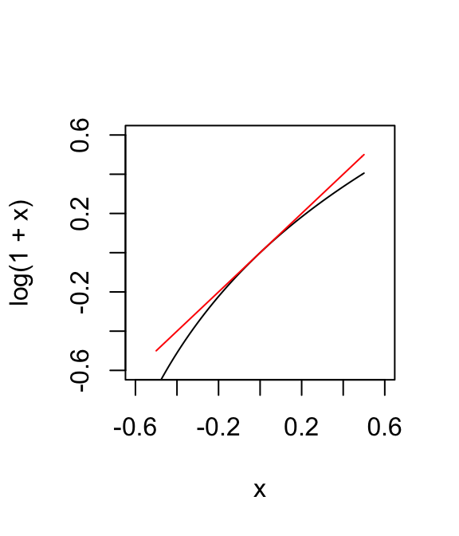

```r
identidad <- function(x){x}
curve(log(1+x), from=-1/2,to=1/2, xlim=c(-0.6,0.6), ylim=c(-0.6,0.6))
curve(identidad, from=-1/2, to=1/2, col="red", add=TRUE)
```

Podemos verificar estas aproximaciones:

```r
ventas.campeche <- subset(ventas.1, edo == "Campeche")
cuantiles.camp <- quantile(ventas.campeche$trans1)
cuantiles.camp[4]/cuantiles.camp[3]
# 2.719
cuantiles.camp[2]/cuantiles.camp[3]
# 0.7023
```

### Referencias

- Willam S. Cleveland, Visualizing Data, Hobart Press, 1994.
- Hyndman y Fan. Sample quantiles in statistical packages, The American Statistician, 1996.
- B.D. Ripley, Robust Statistics, 2004.
- David W. Scott, Multivariate Density Estimation, Wiley & Sons, 1992.
- John W. Tukey y Frederick Mosteller, Data Analysis and Regression, Addison-Wesley, 1977.
- Izenman y Sommer, Philatelic mixtures and multimodal densities, Journal of the American Statistical Association, 1998.